# Analysis of longitudinal data

In this chapter I am going to demonstrate techniques used to analyze longitudinal data.

```r
# reading the data for this chapter
RATSL <- read.table(file = "Z:\\Documents\\RProjects\\IODS-project\\data\\RATSL.csv", header = TRUE, sep = ",", row.names = 1)

BPRSL <- read.table(file = "Z:\\Documents\\RProjects\\IODS-project\\data\\BPRSL.csv", header = TRUE, sep = ",", row.names = 1)

# libraries used
library(tidyr)
library(dplyr)
```

```r
library(ggplot2)
library(lme4)
library(cowplot)
```

## Impact of nutrition on growth

### Overview of the data

The first technique – *summary measure approach* – is going to be tested on RATS data set (see [Crowder & Hand 1990](https://www.taylorfrancis.com/books/mono/10.1201/9781315137421/analysis-repeated-measures-crowder-hand)). The data set records weights of three groups of rats on different diets over the period of 64 days.

```r
# structure of the data set
glimpse(RATSL)
```

```
## Rows: 176
## Columns: 5
## $ ID      <int> 1, 2, 3, 4, 5, 6, 7, 8, 9, 10, 11, 12, 13, 14, 15, 16, 1, 2, 3~
## $ Group   <int> 1, 1, 1, 1, 1, 1, 1, 1, 2, 2, 2, 2, 3, 3, 3, 3, 1, 1, 1, 1, 1,~
## $ days    <chr> "WD1", "WD1", "WD1", "WD1", "WD1", "WD1", "WD1", "WD1", "WD1",~
## $ weights <int> 240, 225, 245, 260, 255, 260, 275, 245, 410, 405, 445, 555, 47~
## $ day     <int> 1, 1, 1, 1, 1, 1, 1, 1, 1, 1, 1, 1, 1, 1, 1, 1, 8, 8, 8, 8, 8,~
```

```r
# transforming categorical variables into factor
cat_vars2 <- c("ID", "Group")
RATSL[cat_vars2] <- lapply(RATSL[cat_vars2], factor)
```

### Graphical display of growth

To start with, let’s investigate plots of growth profiles by group. According to Figure 1.1, all diets seem to result in growth of rat’s body mass, however, group 1 demonstrates a more moderate trend than the other two.

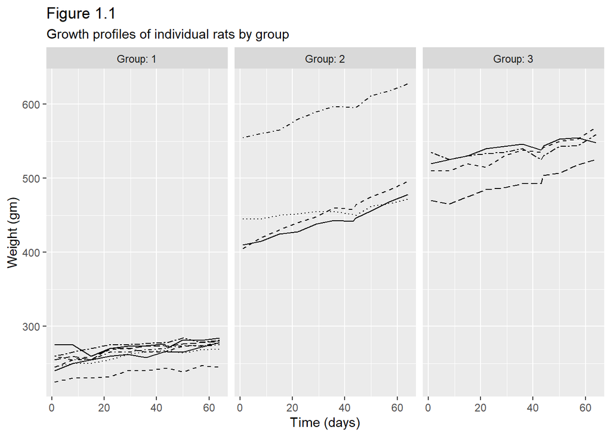

```r
# drawing the plot
ggplot(RATSL, aes(x = day, y = weights, linetype = ID)) +
  geom_line() +
  scale_linetype_manual(values = rep(1:8, times=2)) +
  facet_grid(. ~ Group, labeller = label_both) +
  theme(legend.position = "none") +
  scale_y_continuous(limits = c(min(RATSL$weights), max(RATSL$weights))) + labs(y = "Weight (gm)", x = "Time (days)", title = "Figure 1.1", subtitle = "Growth profiles of individual rats by group")
```

Let’s standardize weights to observe *tracking*, a tendency for subjects with higher values to have higher values throughout the study. Figure 1.2 shows that growth trend for some rats is reversed, and overall, now growth trends appear less dramatic.

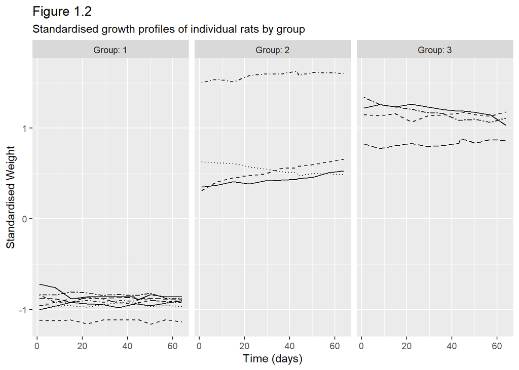

```r
# standardizing weights
RATSL <- RATSL %>% group_by(day) %>%
  mutate(std_weights = scale(weights) )  %>%
  ungroup()

# drawing new plot
ggplot(RATSL, aes(x = day, y = std_weights, linetype = ID)) +
  geom_line() +
  scale_linetype_manual(values = rep(1:8, times=2)) +
  facet_grid(. ~ Group, labeller = label_both) +
  theme(legend.position = "none") +
  scale_y_continuous(limits = c(min(RATSL$std_weights), max(RATSL$std_weights))) + labs(y = "Standardised Weight", x = "Time (days)", title = "Figure 1.2", subtitle = "Standardised growth profiles of individual rats by group")
```

By plotting the means of the three groups, it is possible to observe that the groups appear to have distinct profiles. Although group 2 and 3 seem very close, they do not overlap.

```r
# extracting number of days measurements were made
n <- RATSL$day %>% unique() %>% length()

# summary data with mean and standard error of weights by group and day
RATSS <- RATSL %>%
  group_by(Group, day) %>%
  summarise( mean = mean(weights), se = sd(weights)/sqrt(n) ) %>%
  ungroup()
```

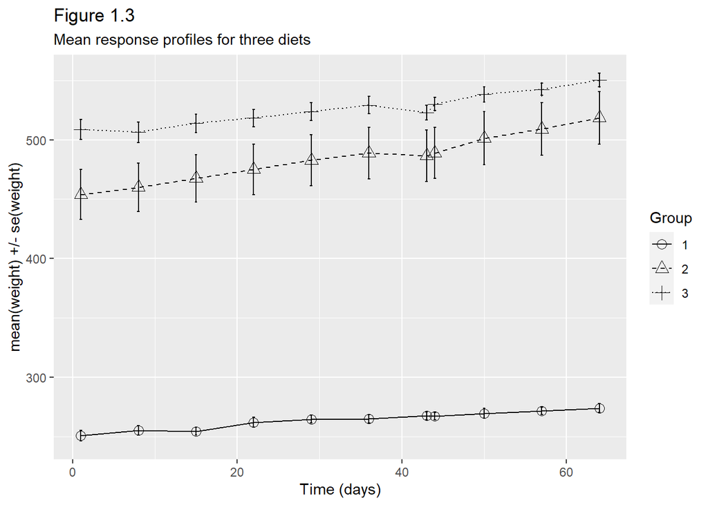

```r
ggplot(RATSS, aes(x = day, y = mean, linetype = Group, shape = Group)) +
  geom_line() +
  scale_linetype_manual(values = c(1,2,3)) +
  geom_point(size=3) +
  scale_shape_manual(values = c(1,2,3)) +
  geom_errorbar(aes(ymin=mean-se, ymax=mean+se, linetype="1"), width=0.3) +
  theme(legend.position = "right") +
  scale_y_continuous(name = "mean(weight) +/- se(weight)") + labs(x = "Time (days)", title = "Figure 1.3", subtitle = "Mean response profiles for three diets")
```

### Summary measure analysis

Summary measure analysis implies exploring the difference between groups on the basis of a single value, which captures some important characteristic of each group. This technique is commonly used as a preliminary stage for longitudinal data analysis. For the purposes of this exercise I am going to use the mean as a summary measure.

Boxplots of mean profiles (Figure 1.4) indicate that groups seem to be different. Group 1 has the least variability. Meanwhile, group 2 and 3 seem somewhat skewed into the opposite directions. The groups have no outliers.

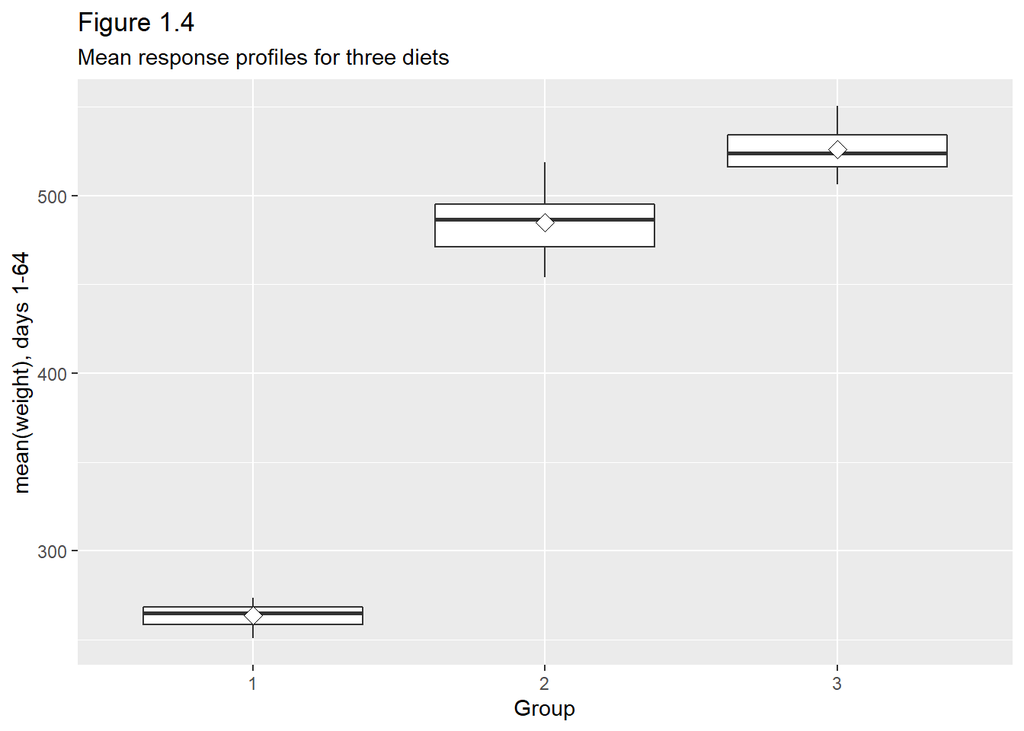

```r
# draw boxplots for groups
ggplot(RATSS, aes(x = Group, y = mean)) +
  geom_boxplot() +
  stat_summary(fun.y = "mean", geom = "point", shape=23, size=3, fill = "white") +
  scale_y_continuous(name = "mean(weight), days 1-64") +
  labs(title = "Figure 1.4", subtitle = "Mean response profiles for three diets")
```

### One-way analysis of variance (ANOVA)

In order to confirm that the diets indeed have a different impact on growth, I am going to conduct one-way analysis of variance (ANOVA) on the means. The resulting *p* value is smaller than 0.05, thus, we can conclude that groups 2 and 3 differ significantly from group 1. Next, I am performing a post hoc test (Tuckey test), to be sure that all groups also differ from each other. As *p* values of the test suggest, it is indeed so.

```r
# fitting anova
ratss_aov <- aov(mean ~  Group, data = RATSS)
summary(ratss_aov)
```

```
##             Df Sum Sq Mean Sq F value Pr(>F)
## Group        2 437104  218552    1006 <2e-16 ***
## Residuals   30   6516     217
## ---
## Signif. codes:  0 '***' 0.001 '**' 0.01 '*' 0.05 '.' 0.1 ' ' 1
```

```r
# post-hoc test
TukeyHSD(ratss_aov)
```

```
##   Tukey multiple comparisons of means
##     95% family-wise confidence level
##
## Fit: aov(formula = mean ~ Group, data = RATSS)
##
## $Group
##          diff       lwr       upr p adj
## 2-1 220.98864 205.49700 236.48027 0e+00
## 3-1 262.07955 246.58791 277.57118 0e+00
## 3-2  41.09091  25.59927  56.58254 9e-07
```

## Effects of different treatments on brief psychiatric rating scale

### Overview of the data

In this section I am going to use *linear mixed effect model* approach. For this exercise I am using the data set from [Davis 2002](https://link.springer.com/book/10.1007/b97287). It is taken from brief psychiatric rating scale (BPRS) study conducted over a period of 9 weeks on 40 men, who were divided into two treatment groups.

```r
# structure of the data
glimpse(BPRSL)
```

```
## Rows: 360
## Columns: 6
## $ treatment <int> 1, 1, 1, 1, 1, 1, 1, 1, 1, 1, 1, 1, 1, 1, 1, 1, 1, 1, 1, 1, ~
## $ subject   <int> 1, 2, 3, 4, 5, 6, 7, 8, 9, 10, 11, 12, 13, 14, 15, 16, 17, 1~
## $ id        <int> 1, 2, 3, 4, 5, 6, 7, 8, 9, 10, 11, 12, 13, 14, 15, 16, 17, 1~
## $ weeks     <chr> "week0", "week0", "week0", "week0", "week0", "week0", "week0~
## $ bprs      <int> 42, 58, 54, 55, 72, 48, 71, 30, 41, 57, 30, 55, 36, 38, 66, ~
## $ week      <int> 0, 0, 0, 0, 0, 0, 0, 0, 0, 0, 0, 0, 0, 0, 0, 0, 0, 0, 0, 0, ~
```

```r
# transforming categorical variables into factors
cat_vars <- c("treatment", "subject", "id")
BPRSL[cat_vars] <- lapply(BPRSL[cat_vars], factor)
```

### Graphical display

First, let’s graphically explore the data (Figure 2.1). At first glance, both groups express a downward trend in BPRS measure. The plot does not reveal an obvious diffetence between two treatments.

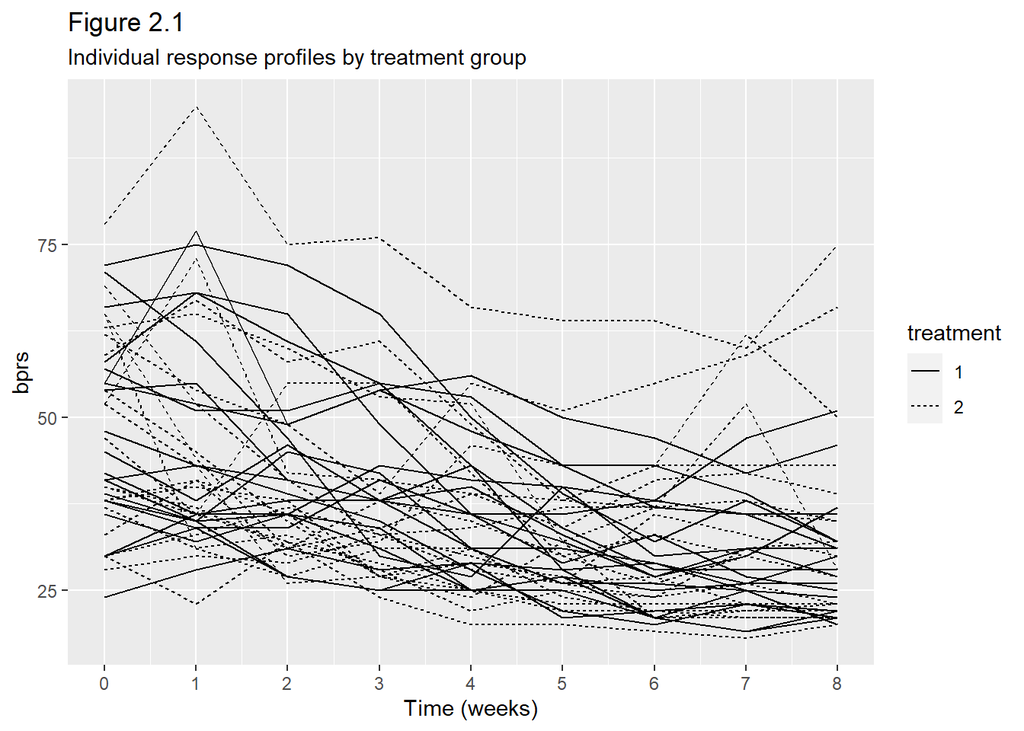

```r
obs_plot <- ggplot(BPRSL, aes(x = week, y = bprs, group = id)) +
  geom_line(aes(linetype = treatment)) +
  scale_x_continuous(name = "Time (weeks)", breaks = seq(0, 8, 1))

obs_plot +
  labs(title = "Figure 2.1", subtitle= "Individual response profiles by treatment group")
```

### Assuming independence

Before testing linear mixed effect modelling, I am going to wrongly (!) assume that the measurements are independent from each other and fit a multiple linear regression model. In other words, I treat the data set as if there are 360 observations from different people. Ignoring within-subject dependencies leads to higher standard error estimates for the `week` regression coefficient. In this case it is 0.2524.

```r
# fit model assuming independence
bprs_m0 <- lm(bprs ~ week + treatment, data = BPRSL)
summary(bprs_m0)
```

```
##
## Call:
## lm(formula = bprs ~ week + treatment, data = BPRSL)
##
## Residuals:
##     Min      1Q  Median      3Q     Max
## -22.454  -8.965  -3.196   7.002  50.244
##
## Coefficients:
##             Estimate Std. Error t value Pr(>|t|)
## (Intercept)  46.4539     1.3670  33.982   <2e-16 ***
## week         -2.2704     0.2524  -8.995   <2e-16 ***
## treatment2    0.5722     1.3034   0.439    0.661
## ---
## Signif. codes:  0 '***' 0.001 '**' 0.01 '*' 0.05 '.' 0.1 ' ' 1
##
## Residual standard error: 12.37 on 357 degrees of freedom
## Multiple R-squared:  0.1851, Adjusted R-squared:  0.1806
## F-statistic: 40.55 on 2 and 357 DF,  p-value: < 2.2e-16
```

### Linear mixed effects models

Now I am going to demonsterate more appropriate models for repeated measurements data.

First, I am fitting a mixed effect model with random intercept. By allowing the intercept to be different we can account for difference between subjects. Immediately we can observe that standard error for `week` is considerably lower – only 0.1503.

Regression coefficient for `treatment` has a very low t-value, which suggests that that the null hypothesis might be true, and there is no difference between the two groups.

Nevertheless, I am going to do another fit with random intercept and random slope. This model allows duration of treatment to have an effect on the slope. Again, t-value for `treatment` is close to 0.

Next, we are going to allow interaction between treatment and time. In this case too, the result appears to suggest that the treatment does not have a different effect on BPRS.

```r
# fit model with random intercept
bprs_m1 <- lmer(bprs ~ week + treatment + (1|id), data = BPRSL, REML = FALSE)
summary(bprs_m1)
```

```
## Linear mixed model fit by maximum likelihood  ['lmerMod']
## Formula: bprs ~ week + treatment + (1 | id)
##    Data: BPRSL
##
##      AIC      BIC   logLik deviance df.resid
##   2582.9   2602.3  -1286.5   2572.9      355
##
## Scaled residuals:
##      Min       1Q   Median       3Q      Max
## -2.27506 -0.59909 -0.06104  0.44226  3.15835
##
## Random effects:
##  Groups   Name        Variance Std.Dev.
##  id       (Intercept) 97.39    9.869
##  Residual             54.23    7.364
## Number of obs: 360, groups:  id, 40
##
## Fixed effects:
##             Estimate Std. Error t value
## (Intercept)  46.4539     2.3521  19.750
## week         -2.2704     0.1503 -15.104
## treatment2    0.5722     3.2159   0.178
##
## Correlation of Fixed Effects:
##            (Intr) week
## week       -0.256
## treatment2 -0.684  0.000
```

```r
# fit model with random intercept and random slope
bprs_m2 <- lmer(bprs ~ week + treatment + (week|id), data = BPRSL, REML = FALSE)
summary(bprs_m2)
```

```
## Linear mixed model fit by maximum likelihood  ['lmerMod']
## Formula: bprs ~ week + treatment + (week | id)
##    Data: BPRSL
##
##      AIC      BIC   logLik deviance df.resid
##   2523.2   2550.4  -1254.6   2509.2      353
##
## Scaled residuals:
##     Min      1Q  Median      3Q     Max
## -2.4655 -0.5150 -0.0920  0.4347  3.7353
##
## Random effects:
##  Groups   Name        Variance Std.Dev. Corr
##  id       (Intercept) 167.827  12.955
##           week          2.331   1.527   -0.67
##  Residual              36.747   6.062
## Number of obs: 360, groups:  id, 40
##
## Fixed effects:
##             Estimate Std. Error t value
## (Intercept)  45.9830     2.6470  17.372
## week         -2.2704     0.2713  -8.370
## treatment2    1.5139     3.1392   0.482
##
## Correlation of Fixed Effects:
##            (Intr) week
## week       -0.545
## treatment2 -0.593  0.000
```

```r
# compare models
anova(bprs_m1, bprs_m2)
```

```
## Data: BPRSL
## Models:
## bprs_m1: bprs ~ week + treatment + (1 | id)
## bprs_m2: bprs ~ week + treatment + (week | id)
##         npar    AIC    BIC  logLik deviance  Chisq Df Pr(>Chisq)
## bprs_m1    5 2582.9 2602.3 -1286.5   2572.9
## bprs_m2    7 2523.2 2550.4 -1254.6   2509.2 63.663  2  1.499e-14 ***
## ---
## Signif. codes:  0 '***' 0.001 '**' 0.01 '*' 0.05 '.' 0.1 ' ' 1
```

```r
# fit model with random intercept, random slope and interaction
bprs_m3 <- lmer(bprs ~ week + treatment + week*treatment + (week|id), data = BPRSL, REML = FALSE)
summary(bprs_m3)
```

```
## Linear mixed model fit by maximum likelihood  ['lmerMod']
## Formula: bprs ~ week + treatment + week * treatment + (week | id)
##    Data: BPRSL
##
##      AIC      BIC   logLik deviance df.resid
##   2523.5   2554.5  -1253.7   2507.5      352
##
## Scaled residuals:
##     Min      1Q  Median      3Q     Max
## -2.4747 -0.5256 -0.0866  0.4435  3.7884
##
## Random effects:
##  Groups   Name        Variance Std.Dev. Corr
##  id       (Intercept) 164.204  12.814
##           week          2.203   1.484   -0.66
##  Residual              36.748   6.062
## Number of obs: 360, groups:  id, 40
##
## Fixed effects:
##                 Estimate Std. Error t value
## (Intercept)      47.8856     2.9840  16.047
## week             -2.6283     0.3752  -7.006
## treatment2       -2.2911     4.2200  -0.543
## week:treatment2   0.7158     0.5306   1.349
##
## Correlation of Fixed Effects:
##             (Intr) week   trtmn2
## week        -0.668
## treatment2  -0.707  0.473
## wek:trtmnt2  0.473 -0.707 -0.668
```

```r
# compare models again
anova(bprs_m2, bprs_m3)
```

```
## Data: BPRSL
## Models:
## bprs_m2: bprs ~ week + treatment + (week | id)
## bprs_m3: bprs ~ week + treatment + week * treatment + (week | id)
##         npar    AIC    BIC  logLik deviance Chisq Df Pr(>Chisq)
## bprs_m2    7 2523.2 2550.4 -1254.6   2509.2
## bprs_m3    8 2523.5 2554.6 -1253.7   2507.5  1.78  1     0.1821
```

### Comparison between observed and predicted

Finally, I am going to show the earlier graph with observed values next to the one with fitted values (Figure 2.2). Looks rather accurate.

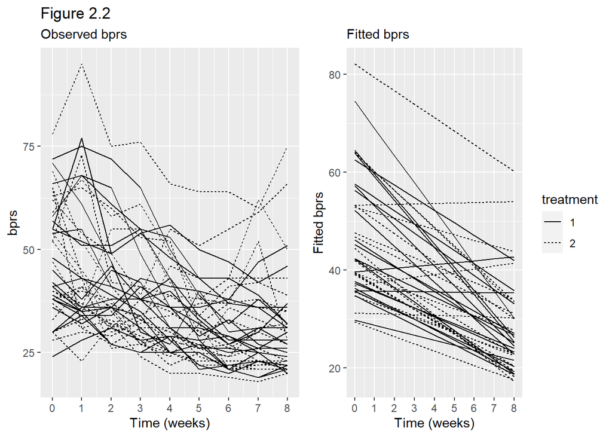

```r
# create new column with fitted bprs
Fitted <- fitted(bprs_m2)
BPRSL <- BPRSL %>% mutate(Fitted = Fitted)

# draw plots
fit_plot <- ggplot(BPRSL, aes(x = week, y = Fitted, group = id)) +
  geom_line(aes(linetype = treatment)) +
  scale_x_continuous(name = "Time (weeks)", breaks = seq(0, 8, 1)) +
  scale_y_continuous(name = "Fitted bprs")


plot_grid(obs_plot + theme(legend.position = "none") + labs(title = "Figure 2.2", subtitle = "Observed bprs"),
          fit_plot + labs(title = " ", subtitle = "Fitted bprs"),
          labels = NULL)
```